# Regresión múltiple

Caso de estudio: La evaluación de los docentes en función de dos variables, género y edad. Una varible categórica y una variable numérica.

Se utiliza el dataset `evals` incluido en el paquete `moderndive`.

En primera instancia crearemos un dataset conteniendo únicamente las tres varaibles de interés. Las dos variables explicativas $X$ y la variable objetivo $y$.

```r
evaluaciones <- evals %>%
  select(ID, score, age, gender)
evaluaciones
```

| ID | score | age | gender |
| --- | --- | --- | --- |
| 1 | 4.7 | 36 | female |
| 2 | 4.1 | 36 | female |
| 3 | 3.9 | 36 | female |
| 4 | 4.8 | 36 | female |
| 5 | 4.6 | 59 | male |
| 6 | 4.3 | 59 | male |
| 7 | 2.8 | 59 | male |
| 8 | 4.1 | 51 | male |
| 9 | 3.4 | 51 | male |
| 10 | 4.5 | 40 | female |

[output cut: 453 more lines]

## Exploarción de datos mediante tres pasos:

1. Observación de los datos: estructura y valores.
2. Cálculo de estadísticas descriptivas que proveen información útil
3. Visualización de datos mediante gráficas que aportan más información

### Observación de los valores de los datos

| ID | score | age | gender |
| --- | --- | --- | --- |
| 132 | 3.6 | 62 | male |
| 102 | 4.9 | 46 | female |
| 331 | 4.6 | 64 | male |
| 151 | 3.8 | 52 | male |
| 413 | 4.0 | 47 | female |
| 177 | 4.4 | 39 | male |
| 438 | 3.0 | 62 | male |

## Estadísticas descriptivas

### Correlación entre las dos variables numéricas

| cor |
| --- |
| -0.107032 |

## Exploración visual de los datos

### Gráfica de dispersión

Las variables numéricas se utilizarán para generar los puntos mientras que la varaible de género se incorpara al gráfico mediante el color de los puntos.

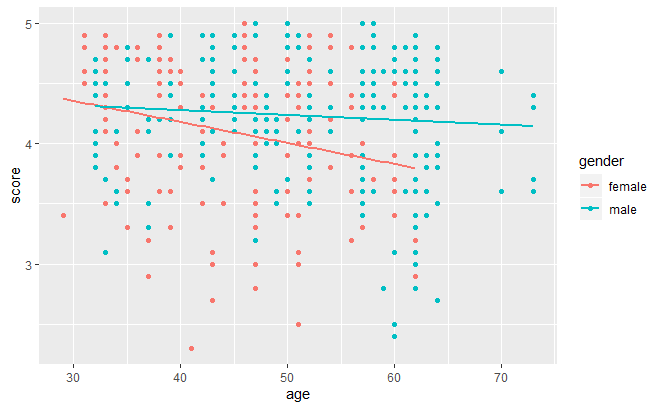

## Modelo de regresión lineal múltiple

La fórmula en este caso debe incluir las dos variables en cuestión `gender` y `age`, en la formula las asociamos con un signo de multiplicación, de la siguiente manera: `y = x1 * x2`.

| term | estimate | std_error | statistic | p_value | lower_ci | upper_ci |
| --- | --- | --- | --- | --- | --- | --- |
| intercept | 4.883 | 0.205 | 23.795 | 0.000 | 4.480 | 5.286 |
| age | -0.018 | 0.004 | -3.919 | 0.000 | -0.026 | -0.009 |
| gendermale | -0.446 | 0.265 | -1.681 | 0.094 | -0.968 | 0.076 |
| age:gendermale | 0.014 | 0.006 | 2.446 | 0.015 | 0.003 | 0.024 |

¿Qué pasa con la intercección y la pendiente del género masculino?

La siguiente tabla muestra los datos de forma completa:

| Gender | Intercept | Slope for age |
| --- | --- | --- |
| Female instructors | 4.883 | -0.018 |
| Male instructors | 4.437 | -0.004 |

Esto significa que en promedio un instructor femenino que es un año mayor, tiene una evaluación que es *0.018 unidades menor*. Para los instructores masculinos, el decrecimiento en la evaluación debido a la edad es menor (0.004 unidades). Esto sugiere que en las evaluaciones escolares, la edad impacta de forma más importante en los instructores femeninos que en los masculinos.

La ecuación para calcular $\hat{y} = score$ es:
$$\widehat{y} = b_0 + b_{\text{age}} \cdot \text{age} + b_{\text{male}} \cdot \mathbb{1}_{\text{is male}}(x) + b_{\text{age,male}} \cdot \text{age} \cdot \mathbb{1}_{\text{is male}}\\
= 4.883 -0.018 \cdot \text{age} - 0.446 \cdot \mathbb{1}_{\text{is male}}(x) + 0.014 \cdot \text{age} \cdot \mathbb{1}_{\text{is male}}$$
donde

$$\mathbb{1}_{\text{is male}}(x) = \left\{
\begin{array}{ll}
1 & \text{si el instructor } x \text{es masculino}\\
0 & \text{de otra manera}\end{array}
\right.$$

Por ejemplo, para estimar el valor de $\hat{y}$ para instructores femeninos, la f´rmula quedaría:
$$\begin{aligned}
\widehat{y} = \widehat{\text{score}} &= 4.883 - 0.018 \cdot \text{age} - 0.446 \cdot 0 + 0.014 \cdot \text{age} \cdot 0\\
&= 4.883 - 0.018 \cdot \text{age} - 0 + 0\\
&= 4.883 - 0.018 \cdot \text{age}\\
\end{aligned}$$

Mientras que para los instructores maculinos, la ecuación sería:

$$\begin{aligned}
\widehat{y} = \widehat{\text{score}} &= 4.883 - 0.018 \cdot \text{age} - 0.446 + 0.014 \cdot \text{age}\\
&= (4.883 - 0.446) + (- 0.018 + 0.014) * \text{age}\\
&= 4.437 - 0.004 \cdot \text{age}\\
\end{aligned}$$

## Otro ejemplo del modelo de regresión lineal

| Sujetos | inteligencia | motivación | rendimiento |
| --- | --- | --- | --- |
| 1 | 85 | baja | 5 |
| 2 | 100 | baja | 8 |
| 3 | 95 | baja | 7 |
| 4 | 80 | baja | 4 |
| 5 | 115 | baja | 10 |
| 6 | 90 | baja | 6 |
| 7 | 100 | alta | 6 |
| 8 | 105 | alta | 7 |
| 9 | 85 | alta | 9 |
| 10 | 80 | alta | 9 |

[output cut: 2 more lines]

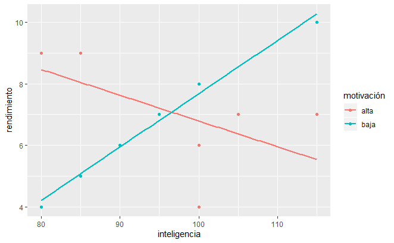

### Modelo de regresión múltiple

| term | estimate | std_error | statistic | p_value | lower_ci | upper_ci |
| --- | --- | --- | --- | --- | --- | --- |
| intercept | 15.149 | 4.228 | 3.583 | 0.007 | 5.398 | 24.900 |
| inteligencia | -0.084 | 0.043 | -1.941 | 0.088 | -0.183 | 0.016 |
| motivaciónbaja | -24.771 | 6.000 | -4.129 | 0.003 | -38.606 | -10.935 |
| inteligencia:motivaciónbaja | 0.257 | 0.062 | 4.125 | 0.003 | 0.113 | 0.400 |

Ecuación de regresión estimada

$$\hat{y} = b_{0} + b_{inteligencia} \cdot inteligencia + \\
b_{motivación}\cdot 1_{\text{es baja}}(x) + \\
b_{int:mot}\cdot inteligencia \cdot 1_{\text{es motivación_baja}}(x)\\
= 15.149 - 0.084\cdot inteligencia - \\
24.771 \cdot1_{\text{si es motivación_baja}}(x) + \\
0.257\cdot inteligencia\cdot 1_{\text{si es motivación_baja}}(x)$$

| y | y1 |
| --- | --- |
| 5.083 | -8.528000 |
| 7.678 | -9.788000 |
| 6.813 | -9.368000 |
| 4.218 | -8.108000 |
| 10.273 | -11.048000 |
| 5.948 | -8.948000 |
| 6.749 | -8.901167 |
| 6.329 | -8.036167 |
| 8.009 | -11.496167 |
| 8.429 | -12.361167 |

[output cut: 2 more lines]

La siguiente es la ecuación de los resultados del autor del ejemplo sin embargo la aproximación resulta más lejana que la resultante por el método que el librop moderndive propone. https://personal.us.es/avelarde/analisisdos/Interaccion%20en%20regresion.pdf

Si hacemos el cálculo y la comparación tenemos

| nuestro_ejemplo | ejemplo_del_libro | dato_observado |
| --- | --- | --- |
| 5.083 | -8.528000 | 5 |
| 7.678 | -9.788000 | 8 |
| 6.813 | -9.368000 | 7 |
| 4.218 | -8.108000 | 4 |
| 10.273 | -11.048000 | 10 |
| 5.948 | -8.948000 | 6 |
| 6.749 | -8.901167 | 6 |
| 6.329 | -8.036167 | 7 |
| 8.009 | -11.496167 | 9 |
| 8.429 | -12.361167 | 9 |

[output cut: 2 more lines]

Si calculamos el error en ambos casos tenemos

Vemos que el error del método que propone moderdive (12.43) respecto al error que propone el documento en internet (3248.413) es mucho menor.

Si generamos el modelo a partir de considerar la motivación como dato numérico (0,1), obtenemos resultados distintos en los coeficientes del modelo, sin embargo las predicciones resultan ser muy parecidas al modelo antes generado con la motivación como dato categórico.

| term | estimate | std_error | statistic | p_value | lower_ci | upper_ci |
| --- | --- | --- | --- | --- | --- | --- |
| intercept | -9.622 | 4.256 | -2.260 | 0.054 | -19.437 | 0.194 |
| inteligencia | 0.173 | 0.045 | 3.854 | 0.005 | 0.069 | 0.276 |
| motivación | 24.771 | 6.000 | 4.129 | 0.003 | 10.935 | 38.606 |
| inteligencia:motivación | -0.257 | 0.062 | -4.125 | 0.003 | -0.400 | -0.113 |

Se genera el modelo y se imprimen los resultados predichos por el modelo

```
                        Df Sum Sq Mean Sq F value  Pr(>F)
inteligencia             1  2.707   2.707   1.744 0.22317
motivación               1  0.120   0.120   0.077 0.78803
inteligencia:motivación  1 26.420  26.420  17.018 0.00332 **
Residuals                8 12.420   1.552
---
Signif. codes:  0 ‘***’ 0.001 ‘**’ 0.01 ‘*’ 0.05 ‘.’ 0.1 ‘ ’ 1
        1         2         3         4         5         6         7
 5.081081  7.675676  6.810811  4.216216 10.270270  5.945946  6.791045
        8         9        10        11        12
 6.373134  8.044776  8.462687  6.791045  5.537313
```

## Modelo de pendientes páralelas

El modelo de pendientes paralelas como su nombre lo indica, obliga que las pendientes de todas las líneas resultantes del modelo sean paralelas auqnue tengan diferentes intersecciones. `ggplot2` no provee este método en `geom_smooth`, por lo tanto para utilizarlo es necesario cargar el paquete `moderndive` y utilizar el método `geom_parallel_slopes`.

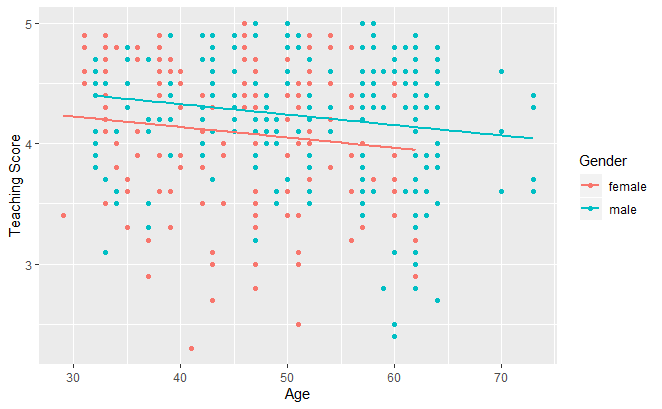

El modelo que se genera para este tipo de aproximación tiene la fórmula `y ~ x1 + x2` en lugar de la fórmula para el modelo de interacción `y ~ x1 *+* x2`.

| term | estimate | std_error | statistic | p_value | lower_ci | upper_ci |
| --- | --- | --- | --- | --- | --- | --- |
| intercept | 4.484 | 0.125 | 35.792 | 0.000 | 4.238 | 4.730 |
| age | -0.009 | 0.003 | -3.280 | 0.001 | -0.014 | -0.003 |
| gendermale | 0.191 | 0.052 | 3.632 | 0.000 | 0.087 | 0.294 |

En el caso de la intesección, nuevamente el dato corresponde al grupo de instructores femeninos (4.484), mientras que la intersección de instructores masculinos será de 4.484 + 0.191 = 4.675. En este caso se tiene un sólo valor para el coeficiente de la edad (-0.009) puesto que la pendiente es la misma para ambos casos. Esto significa que un instructor que es un año mayor que otro, recibe en promedio una puntuación menor en 0.009 unidades. Esto aplic a ambos casos, muejeres y hombres.

La ecuación queda como sigue:
$$\begin{aligned}
\widehat{y} = \widehat{\text{score}} &= b_0 + b_{\text{age}} \cdot \text{age} + b_{\text{male}} \cdot \mathbb{1}_{\text{is male}}(x)\\
&= 4.484 -0.009 \cdot \text{age} + 0.191 \cdot \mathbb{1}_{\text{is male}}(x)
\end{aligned}$$
veamos las dos gráficas juntas

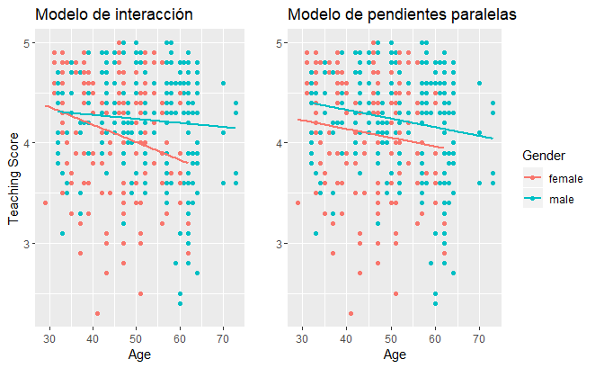